# Introduction to the SLGP Package

## Fitting and checking the model

We now fit the model by MAP on the full range with the completeness trend, and compare the estimated pmf to the empirical frequencies at several longitudes. The fitted mass is essentially zero below $4.0 (as imposed by the trend).

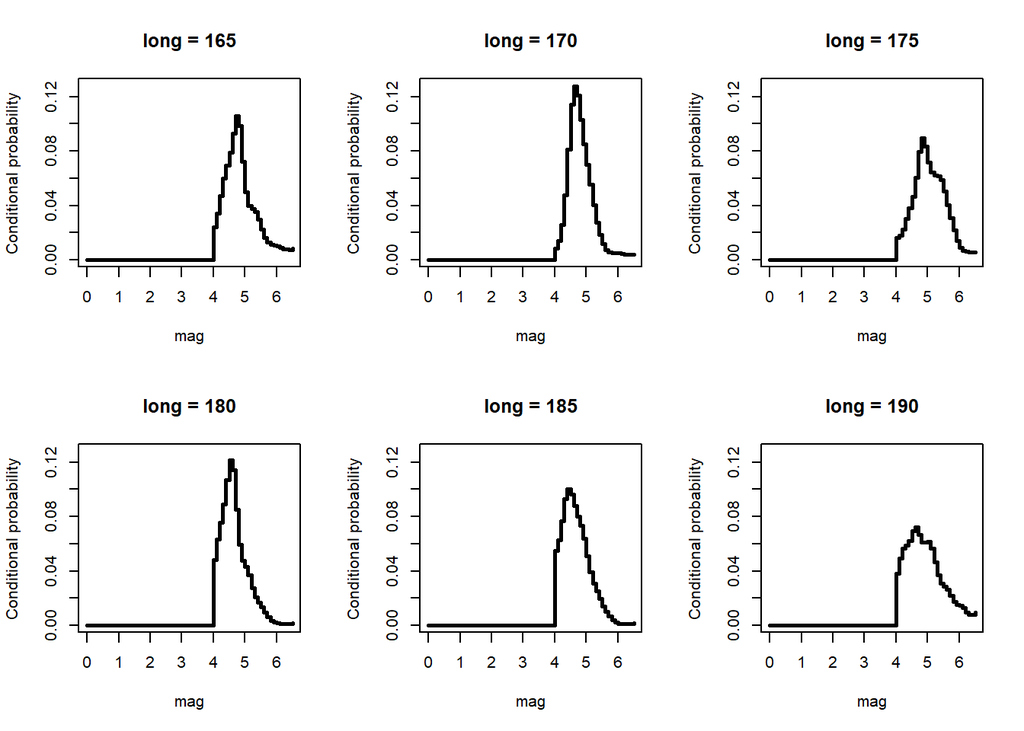

```r
R> modelMAGdisc <- update(priorTrend, newdata=df, method="MAP")
R> plot(modelMAGdisc, draw = "mean", panels = TRUE)
```

```r
R> dev.copy(pdf, "./Figures/defaultMAPDiscrete.pdf", width = 10, height = 3.5)
pdf
  3
R> dev.off()
png
  2
```

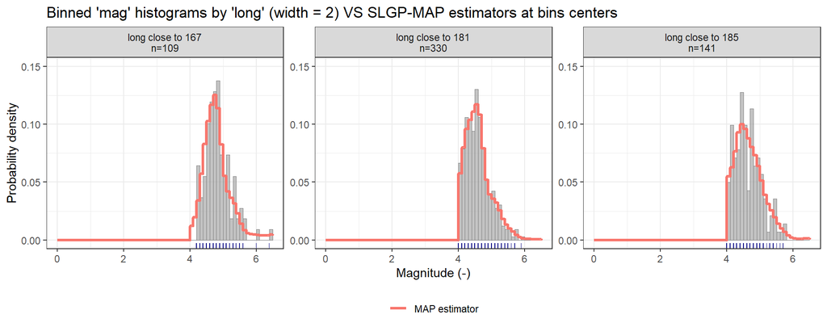

MAP estimate of the conditional probability mass function of magnitude at three longitudes, against the empirical frequencies of the events within 1 degree of each.

```r
R> selected_values <- c(167, 181, 185)
R> gap <- 1.0
R> df_filtered <- df %>%
+    mutate(interval=findInterval(long, c(0,
+                                         selected_values[1]-gap,
+                                         selected_values[1]+gap,
+                                         selected_values[2]-gap,
+                                         selected_values[2]+gap,
+                                         selected_values[3]-gap,
+                                         selected_values[3]+gap)))%>%
+    filter(interval %in% c(2, 4, 6))%>%
+    group_by(interval)%>%
+    mutate(category = paste0("long close to ", c("", selected_values[1],
+                                                 "", selected_values[2],
+                                                 "", selected_values[3])[interval],
+                             "\nn=", n()))
R> names <- sort(unique(df_filtered$category))
R> dfGrid <- data.frame(expand.grid(selected_values,
+                                   seq(range_mag_full[1], range_mag_full[2],, K_full)))
R> colnames(dfGrid) <- c("long", "mag")
R> predMAP <- predict(modelMAGdisc, newdata = dfGrid, discrete=TRUE, nIntegral = K_full)
R> colnames(predMAP) <- c("long", "mag", "MAP estimator")
R> predMAP <- predMAP%>%
+    pivot_longer(-c("long", "mag"))
R> predMAP$category <-ifelse(predMAP$long==selected_values[1], names[1],
+                            ifelse(predMAP$long==selected_values[2], names[2], names[3]))
R>
R> ggplot(mapping=aes(x = mag)) +
+    geom_histogram(df_filtered,
+                   mapping=aes(y = after_stat(density)/10, group=category),
+                   closed = "left", binwidth = 0.1, boundary = 0,
+                   fill="darkgrey", col="grey50", lwd=0.2, alpha=0.7) +
+    geom_rug(data=df_filtered, sides = "b", color = "navy", alpha = 0.5)+
+    geom_step(data=predMAP, mapping=aes(y=value, group=name, col=name), lwd=1.1)+
+    facet_wrap(~ category, scales = "free_y", nrow=1) +
+    labs(x = "Magnitude (-)",
+         y = "Probability density",
+         title = "Binned 'mag' histograms by 'long' (width = 2) VS SLGP-MAP estimators at bins centers")+
+    theme_bw()+
+    theme(legend.position="bottom",
+          legend.direction = "horizontal",
+          legend.title = element_blank())+
+    coord_cartesian(xlim=range_mag_full,
+                    ylim=c(0, 0.15))
```

```r
R>
R> ggsave(paste0("./Figures/histMAPdisc",  ".pdf"), width=10, height=3.5)
```

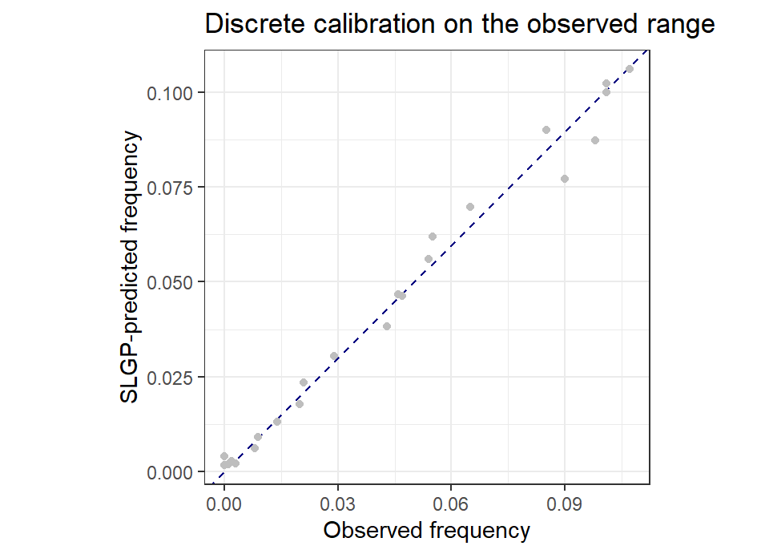

Observed versus SLGP-predicted marginal frequencies of each magnitude level on the observed range, pooled over the dataset Points near the diagonal indicate a well-calibrated discrete fit.

```r
R> obs_freq <- as.numeric(table(factor(round(df$mag, 1), levels = mag_levels))) / nrow(df)
R>
R> # average predicted pmf over the observed longitudes
R> gridPool <- expand.grid(mag = mag_levels, long = df$long)
R> poolPred <- predict(modelMAGdisc, newdata = gridPool, type = "density",
+                      nIntegral = K_full, discrete = TRUE)
R> poolPred$prob <- rowMeans(poolPred[, grep("^pdf_", colnames(poolPred)), drop = FALSE])
R> pred_freq <- tapply(poolPred$prob, poolPred$mag, mean)
R> calib <- data.frame(mag = mag_levels, observed = obs_freq,
+                      predicted = as.numeric(pred_freq[as.character(mag_levels)]))
R>
R> ggplot(calib, aes(x = observed, y = predicted)) +
+    geom_abline(slope = 1, intercept = 0, linetype = 2, colour = "navy") +
+    geom_point(colour = "grey", size = 1.5) +
+    coord_equal() +
+    labs(x = "Observed frequency", y = "SLGP-predicted frequency",
+         title = "Discrete calibration on the observed range") +
+    theme_bw()
```

```r
R> ggsave("./Figures/discreteCalib.pdf", width = 5, height = 3.6)
```

# A bi-dimensional index and continuous response application

Everything so far has indexed the depth distribution by longitude alone. That one-dimensional setting is convenient for slice-based figures, but it is also within reach of many conditional density estimators. The distinctive strength of the SLGP is that nothing in its construction is tied to a scalar index: the model estimates a field of densities over an index domain of any dimension, from scattered and replicate-free data, at no change to the interface.

We now exploit the full epicentre location `(long, lat)` as a two-dimensional index and estimate the conditional distribution of `depth` over the region. This is a regime where per-cell histograms become untenable, since binning a two-dimensional index with 1000 scattered events leaves most cells empty, yet the SLGP applies unchanged.

To obtain an honest assessment of the fit rather than a purely visual one, we adopt a train/test split: the model is trained on a random 75% of the events and validated on the remaining 25%. The figure below shows the two subsets over the region.

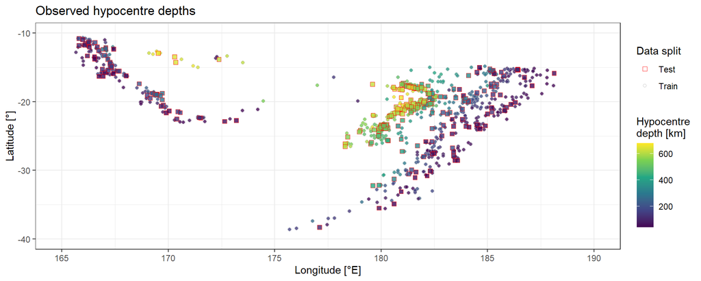

Observed hypocentre depths over the Fiji-Tonga region, split into a 75% training set (grey) and a 25% held-out test set (red). Colour encodes depth.

```r
R> range_response <- c(40, 680) # Can use range(df$depth), or user defined range as we do here
R> range_xlong <- c(165, 190) # Can use range(df$long), or user defined range as we do here
R> range_xlat <- c(-40, -10) # Can use range(df$long), or user defined range as we do here
R>
R> set.seed(1)
R> id_train <- sample(seq_len(nrow(df)), size = floor(0.75 * nrow(df)), replace = FALSE)
R>
R> df_train <- df[id_train, ]
R> df_test  <- df[-id_train, ]
R>
R>
R> map_plot <- ggplot(mapping = aes(x = long, y = lat, fill = depth)) +
+    geom_point(data = df_train, mapping = aes(col = "Train", pch = "Train"),
+               size = 1.5, alpha = 0.8) +
+    geom_point(data = df_test,  mapping = aes(col = "Test",  pch = "Test"),
+               size = 2, alpha = 0.8) +
+    scale_fill_viridis_c(name = "Hypocentre\ndepth [km]",
+                         limits = range_response, option = "viridis") +
+    scale_shape_manual(values = c("Train" = 21, "Test" = 22)) +
+    scale_color_manual(values = c("Train" = "grey", "Test" = "red")) +
+    coord_cartesian(xlim = range_xlong, ylim = range_xlat) +
+    labs(x = "Longitude [°E]", y = "Latitude [°]",
+         title = "Observed hypocentre depths",
+         col = "Data split", shape = "Data split") +
+    theme_bw()
R> map_plot
```

Fitting the two-dimensional model requires only that the index-related arguments grow accordingly: the formula becomes `depth ~ long + lat`, `predictorsLower` and `predictorsUpper` are length two, and the length-scale vector has one entry per index dimension plus one for the response. The estimation scheme, basis and quadrature are otherwise identical to the one-dimensional case.

```r
R> modelMAP2D <- slgp(depth ~ long + lat,
+                     data = df_train,
+                     method = "MAP",
+                     basisFunctionsUsed = "RFF",
+                     interpolateBasisFun = "WNN",
+                     hyperparams = list(lengthscale = rep(0.15, 3), sigma2 = 1),
+                     sigmaEstimationMethod = "heuristic",
+                     predictorsLower = c(range_xlong[1], range_xlat[1]),
+                     predictorsUpper = c(range_xlong[2], range_xlat[2]),
+                     responseRange = range_response,
+                     opts_BasisFun = list(nFreq = 250, MatParam = 5/2),
+                     seed = 1)
R> summary(modelMAP2D)
Summary of a Spatial Logistic Gaussian Process (SLGP) model
  Formula        : depth ~ long + lat
  Response       : depth  in [40, 680]
  Covariate(s)   : long, lat
  Estimation     : MAP
  Basis          : RFF  (rank p = 500)
  Length-scales  : 0.15, 0.15, 0.15
  Variance sigma2: 0.6967
  Data           : 750 obs, 748 distinct covariate value(s)

Estimation diagnostics
  Fitting time      : 14.9s   (setup 10.2s, estimation 4.66s)
  Coefficient draws : 1
  Log-posterior     : 634.894 (at mode for MAP/Laplace)
  Optimiser         : converged
```

## Out-of-sample calibration

Before inspecting the fitted field, we check that it is *calibrated* on data it has never seen. Because the SLGP returns a full predictive distribution at every location, we can apply the probability integral transform (PIT): for eachheld-out event we evaluate the predictive CDF at the observed depth. If the model is well calibrated, these PIT values should be approximately uniform on $[0, 1]$.

We assess this both visually (with a PIT histogram and a uniform quantile-quantile plot) and with two complementary goodness-of-fit tests against the uniform. The Kolmogorov-Smirnov statistic is the largest vertical gap between the empirical and uniform CDFs, and so reacts to a localised departure, while the Cramér-von Mises statistic integrates the squared gap over $[0,1]$, and so reacts to a diffuse, systematic one. Passing both is therefore a stronger check than passing either.

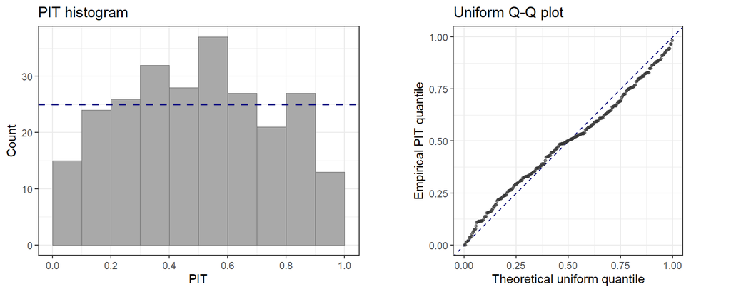

Out-of-sample calibration of the two-dimensional SLGP. Left: PIT histogram of the held-out depths (dashed line: expected count under uniformity). Right: uniform Q-Q plot of the PIT values (points on the diagonal indicate calibration).

```r
R> pit_pred <- predict(modelMAP2D, type = "cdf",
+                      newdata = df_test[, c("long", "lat", "depth")])
R> u <- pit_pred$cdf_1
R>
R> ks.test(u, "punif", 0, 1)

    Asymptotic one-sample Kolmogorov-Smirnov test

data:  u
D = 0.062536, p-value = 0.2822
alternative hypothesis: two-sided
R> library(goftest)
R> cvm.test(u, null = "punif")

    Cramer-von Mises test of goodness-of-fit
    Null hypothesis: uniform distribution
    Parameters assumed to be fixed

data:  u
omega2 = 0.34671, p-value = 0.1003
R>
R> pit_hist <- ggplot(pit_pred, aes(x = cdf_1)) +
+    geom_histogram(breaks = seq(0, 1, by = 0.1),
+                   fill = "darkgrey", colour = "grey40", linewidth = 0.3) +
+    geom_hline(yintercept = nrow(df_test) / 10,
+               linetype = 2, linewidth = 0.8, colour = "navy") +
+    scale_x_continuous(breaks = seq(0, 1, by = 0.2), limits = c(0, 1)) +
+    labs(x = "PIT", y = "Count", title = "PIT histogram") +
+    theme_bw()
R>
R> n_pit <- length(u)
R> qq_df <- data.frame(
+    theoretical = (seq_len(n_pit) - 0.5) / n_pit,   # uniform plotting positions
+    empirical   = sort(u)
+  )
R> pit_qq <- ggplot(qq_df, aes(x = theoretical, y = empirical)) +
+    geom_abline(slope = 1, intercept = 0, linetype = 2, colour = "navy") +
+    geom_point(size = 1, alpha = 0.6, colour = "grey20") +
+    coord_equal(xlim = c(0, 1), ylim = c(0, 1)) +
+    labs(x = "Theoretical uniform quantile", y = "Empirical PIT quantile",
+         title = "Uniform Q-Q plot") +
+    theme_bw()
R>
R> ggarrange(pit_hist, pit_qq, ncol = 2, widths = c(0.5, 0.5))
```

```r
R> ggsave("./Figures/pit2D.pdf", width = 9, height = 3.0)
```

Now that we validated quantitatively, we can also check visual agreement with histograms.

## Reading the fitted field at selected locations

Since the SLGP predicts an entire distribution of `depth` at each `(long, lat)`, visualisation is less direct than in the one-dimensional case. We first inspect the fitted conditional densities at a handful of arbitrary bins, then turn to whole-region summary maps.

For the empirical reference we define a small set of spatial rectangles, retaining their train/test counts, and compare the SLGP density at each rectangle centre with the pooled histogram of datapoints falling inside it (Figure~$\ref{fig:quakes2Dbins}$).

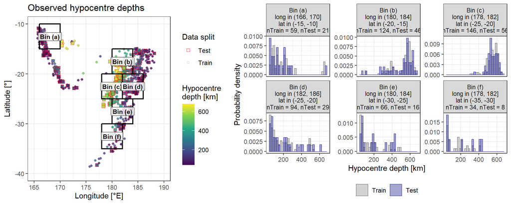

Selected spatial rectangles over the region (left) and, for each, the pooled empirical depth distribution split by train/test (right). Rectangles are labelled (a)-(f).

```r
R> long_min <- c(166, 180, 178, 182, 180, 178)
R> long_max <- c(170, 184, 182, 186, 184, 182)
R> lat_min  <- c(-15, -20, -25, -25, -30, -35)
R> lat_max  <- c(-10, -15, -20, -20, -25, -30)
R>
R> bins <- data.frame(bin_id = seq_along(long_min),
+                     long_min, long_max, lat_min, lat_max) %>%
+    mutate(bin_name = paste0("Bin (", letters[bin_id], ")"))
R>
R> df_train$set <- "Train"; df_test$set <- "Test"
R> df_split <- bind_rows(df_train, df_test) %>%
+    mutate(set = factor(set, levels = c("Train", "Test")))
R>
R> df_selected <- do.call(rbind, lapply(seq_len(nrow(bins)), function(i) {
+    tmp <- df_split %>%
+      filter(long >  bins$long_min[i], long <= bins$long_max[i],
+             lat  >  bins$lat_min[i],  lat  <= bins$lat_max[i])
+    tmp$bin_id <- bins$bin_id[i]; tmp$bin_name <- bins$bin_name[i]
+    tmp
+  }))
R>
R> bin_counts <- df_selected %>%
+    count(bin_id, bin_name, set) %>%
+    tidyr::pivot_wider(names_from = set, values_from = n, values_fill = 0)
R>
R> bins <- bins %>%
+    left_join(bin_counts, by = c("bin_id", "bin_name")) %>%
+    mutate(facet_label = paste0(bin_name, "\n",
+                                "long in (", long_min, ", ", long_max, "]\n",
+                                "lat in (", lat_min, ", ", lat_max, "]\n",
+                                "nTrain = ", Train, ", nTest = ", Test))
R>
R> df_selected <- df_selected %>%
+    left_join(bins %>% select(bin_id, facet_label), by = "bin_id") %>%
+    mutate(facet_label = factor(facet_label, levels = bins$facet_label))
R>
R> hist_plot <- ggplot(df_selected, aes(x = depth, fill = set, colour = set)) +
+    geom_histogram(aes(y = after_stat(density)),
+                   breaks = seq(range_response[1], range_response[2], by = 20),
+                   position = "identity", alpha = 0.35, linewidth = 0.3) +
+    facet_wrap(~ facet_label, nrow = 2, scales = "free_y") +
+    scale_fill_manual(values = c("Train" = "grey50", "Test" = "navy")) +
+    scale_colour_manual(values = c("Train" = "grey30", "Test" = "navy")) +
+    labs(x = "Hypocentre depth [km]", y = "Probability density",
+         fill = NULL, colour = NULL) +
+    coord_cartesian(xlim = range_response) +
+    theme_bw() + theme(legend.position = "bottom")
R>
R> map_plot2 <- map_plot +
+    geom_rect(data = bins,
+              aes(xmin = long_min, xmax = long_max,
+                  ymin = lat_min, ymax = lat_max),
+              inherit.aes = FALSE, fill = NA, colour = "black", linewidth = 0.8) +
+    geom_label(data = bins,
+               aes(x = (long_min + long_max) / 2, y = (lat_min + lat_max) / 2,
+                   label = bin_name),
+               inherit.aes = FALSE, fontface = "bold", size = 3,
+               fill = "white", alpha = 0.8)
R>
R> ggarrange(map_plot2, hist_plot, ncol = 2, nrow = 1, widths = c(0.45, 0.55))
```

```r
R> ggsave("./Figures/scatter2D.pdf", width = 10, height = 4, scale=1.1)
```

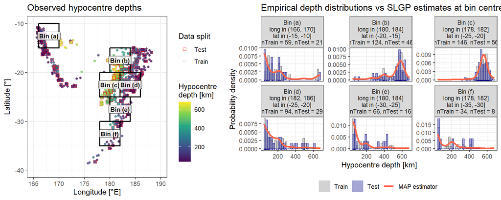

Empirical depth distributions (grey) versus the SLGP conditional density evaluated at the centre of each rectangle (red).

```r
R> bin_centers <- bins %>%
+    mutate(long = (long_min + long_max) / 2, lat = (lat_min + lat_max) / 2)
R>
R> depth_grid <- seq(range_response[1], range_response[2], length.out = 101)
R> dfGrid <- merge(bin_centers %>% select(bin_id, bin_name, facet_label, long, lat),
+                  data.frame(depth = depth_grid))
R>
R> predMAP <- predict(modelMAP2D, newdata = dfGrid %>% select(long, lat, depth))
R> predMAP <- cbind(dfGrid, predMAP %>% select(starts_with("pdf_")))
R>
R>
R> hist_plotMAP <- ggplot(mapping = aes(x = depth)) +
+    geom_histogram(data = df_selected, aes(y = after_stat(density),
+                                           fill = set, colour = set),
+                   breaks = seq(range_response[1], range_response[2], by = 20),
+                   position = "identity", alpha = 0.35, linewidth = 0.3) +
+    geom_rug(data = df_selected, sides = "b", colour = "navy", alpha = 0.5) +
+    geom_line(data = predMAP,
+              aes(y = pdf_1, group = "MAP estimator", col = "MAP estimator"),
+              linewidth = 1.1) +
+    scale_fill_manual(values = c("Train" = "grey50", "Test" = "navy")) +
+    scale_colour_manual(values = c("Train" = "grey30", "Test" = "navy",
+                                   "MAP estimator" = "tomato"))+
+    guides(colour = guide_legend(
+      override.aes = list(fill = c("grey50", "navy", NA),
+                          colour = c("grey30", "navy", "tomato"),
+                          linetype = c(0, 0, 1))),
+      fill = "none")+
+    facet_wrap(~ facet_label, scales = "free_y", nrow = 2) +
+    labs(x = "Hypocentre depth [km]", y = "Probability density",
+         title = "Empirical depth distributions vs SLGP estimates at bin centres") +
+    coord_cartesian(xlim = range_response) +
+    theme_bw() +
+    theme(legend.position = "bottom", legend.direction = "horizontal",
+          legend.title = element_blank())
R> ggsave(hist_plotMAP, file="./Figures/scatter2DMAPa.pdf", width = 10, height = 4)
R>
R> ggarrange(map_plot2, hist_plotMAP, ncol = 2, nrow = 1, widths = c(0.45, 0.55))
```

```r
R> ggsave("./Figures/scatter2DMAPc.pdf", width = 10, height = 4, scale=1.1)
R>
```

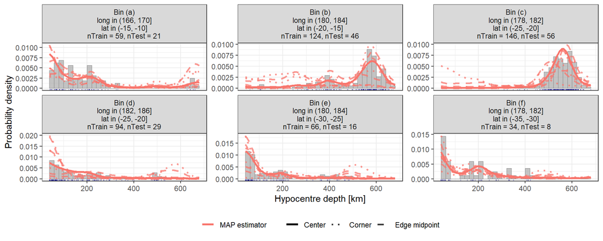

SLGP conditional depth densities evaluated across each rectangle (centre, edge midpoints, corners), against the pooled empirical histogram. A wide spread of curves indicates within-rectangle spatial heterogeneity of the conditional distribution.

```r
R> eval_locations <- bind_rows(
+    bins %>% transmute(bin_id, facet_label, location = "Center",
+                       long = (long_min + long_max)/2, lat = (lat_min + lat_max)/2),
+    bins %>% transmute(bin_id, facet_label, location = "SW", long = long_min, lat = lat_min),
+    bins %>% transmute(bin_id, facet_label, location = "SE", long = long_max, lat = lat_min),
+    bins %>% transmute(bin_id, facet_label, location = "NW", long = long_min, lat = lat_max),
+    bins %>% transmute(bin_id, facet_label, location = "NE", long = long_max, lat = lat_max),
+    bins %>% transmute(bin_id, facet_label, location = "N",
+                       long = (long_min + long_max)/2, lat = lat_max),
+    bins %>% transmute(bin_id, facet_label, location = "S",
+                       long = (long_min + long_max)/2, lat = lat_min),
+    bins %>% transmute(bin_id, facet_label, location = "E",
+                       long = long_max, lat = (lat_min + lat_max)/2),
+    bins %>% transmute(bin_id, facet_label, location = "W",
+                       long = long_min, lat = (lat_min + lat_max)/2))
R>
R> dfGrid_locations <- merge(eval_locations, data.frame(depth = depth_grid))
R> pred_locations <- predict(modelMAP2D, type = "density",
+                            newdata = dfGrid_locations %>% select(long, lat, depth))
R> pred_locations <- cbind(dfGrid_locations,
+                          pred_locations %>% select(starts_with("pdf_"))) %>%
+    rename(value = pdf_1) %>%
+    mutate(location_type = case_when(
+      location == "Center" ~ "Center",
+      location %in% c("N", "S", "E", "W") ~ "Edge midpoint",
+      TRUE ~ "Corner"))
R>
R> ggplot(mapping = aes(x = depth)) +
+    geom_histogram(data = df_selected, aes(y = after_stat(density)),
+                   breaks = seq(40, 680, by = 20),
+                   fill = "darkgrey", colour = "grey50",
+                   linewidth = 0.2, alpha = 0.7) +
+    geom_rug(data = df_selected, sides = "b", colour = "navy", alpha = 0.4) +
+    geom_line(data = pred_locations %>% filter(location != "Center"),
+              aes(y = value, group = interaction(location, facet_label),
+                  linetype = location_type, col = "MAP estimator"),
+              linewidth = 0.95, alpha = 0.75) +
+    geom_line(data = pred_locations %>% filter(location == "Center"),
+              aes(y = value, group = "Center", linetype = "Center",
+                  col = "MAP estimator"), linewidth = 1.2) +
+    facet_wrap(~ facet_label, nrow = 2, scales = "free_y") +
+    scale_linetype_manual(values = c("Center" = 1, "Edge midpoint" = 2, "Corner" = 3)) +
+    labs(x = "Hypocentre depth [km]", y = "Probability density",
+         linetype = "SLGP evaluation location") +
+    coord_cartesian(xlim = range_response) +
+    theme_bw() +
+    theme(legend.position = "bottom", legend.direction = "horizontal",
+          legend.title = element_blank())
```

```r
R> ggsave(paste0("./Figures/histMAPdiscB",  ".pdf"), width=10, height=3.5)
```

The curves confirm the interpretation: within a single rectangle the SLGP density can shift substantially between centre, edges and corners, precisely in the bins where the pooled histogram disagreed with the centre estimate. The earlier discrepancies are therefore consistent with genuine within-rectangle spatial heterogeneity captured by the model, rather than a systematic lack of fit and they illustrate why aggregating a spatially varying field into arbitrary bins, a practice the SLGP is designed to avoid, can be misleading.

## Whole-region summary maps

Evaluating a scalar functional of the fitted distribution on a dense grid turns the density field into an interpretable map. Because the SLGP provides the entire conditional distribution at each location, any such functional (moments, quantiles, or exceedance probabilities) is available from the same fitted object. Figure~$\ref{fig:quakes2Dmoments}$ maps the conditional mean and standard deviation of `depth`.

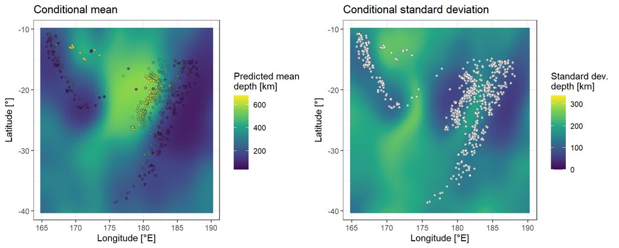

Conditional mean (left) and standard deviation (right) of hypocentre depth over the region, from the two-dimensional SLGP. Points are the observed epicentres; the mean map is coloured by observed depth on the same scale.

```r
R> grid2D <- expand.grid(long = seq(range_xlong[1], range_xlong[2], length.out = 50),
+                        lat  = seq(range_xlat[1],  range_xlat[2],  length.out = 50))
R>
R> pred_mean <- predict(modelMAP2D, type = "moments", newdata = grid2D,
+                       power = c(1), centered = FALSE)
R> pred_sd   <- predict(modelMAP2D, type = "moments", newdata = grid2D,
+                       power = c(2), centered = TRUE)
R>
R> pan_mean <- ggplot() +
+    geom_raster(data = pred_mean, aes(x = long, y = lat, fill = mSLGP_1),
+                interpolate=TRUE) +
+    geom_point(data = df_train, aes(x = long, y = lat, fill = depth),
+               inherit.aes = FALSE, shape = 21, size = 1.4,
+               colour = "grey20", alpha = 0.65, stroke = 0.2) +
+    scale_fill_viridis_c(name = "Predicted mean\ndepth [km]",
+                         limits = range_response, option = "viridis") +
+    coord_cartesian(xlim = range_xlong, ylim = range_xlat) +
+    labs(x = "Longitude [°E]", y = "Latitude [°]", title = "Conditional mean") +
+    theme_bw()
R>
R> pan_sd <- ggplot() +
+    geom_raster(data = pred_sd, aes(x = long, y = lat, fill = sqrt(mSLGP_1)),
+                interpolate=TRUE) +
+    geom_point(data = df_train, aes(x = long, y = lat),
+               inherit.aes = FALSE, shape = 21, size = 1.4,
+               colour = "grey20", fill = "white", alpha = 0.65, stroke = 0.2) +
+    scale_fill_viridis_c(name = "Standard dev.\ndepth [km]",
+                         limits = c(0, range_response[2] / 2), option = "viridis") +
+    coord_cartesian(xlim = range_xlong, ylim = range_xlat) +
+    labs(x = "Longitude [°E]", y = "Latitude [°]",
+         title = "Conditional standard deviation") +
+    theme_bw()
R>
R> ggarrange(pan_mean, pan_sd, ncol = 2, nrow = 1, widths = c(0.5, 0.5))
```

```r
R> ggsave("./Figures/pred2D.pdf", width = 10, height = 4)
```

The mean map traces the deepening of seismicity from the shallow trench in the east towards the deep intraslab events in the west, while the standard-deviation map is largest in the transition zone, where shallow and deep events coexist and the conditional distribution is most dispersed.

A complementary and informative view retains the full distributional information through spatially varying exceedance probabilities.

Since the SLGP estimates the entire conditional distribution at each location, the probability $P(\text{depth} > u \mid \text{long}, \text{lat})$ of an event deeper than a threshold $u$ is read directly from the predictive CDF, for any threshold. Figure~$\ref{fig:quakes2Dexceed}$ maps this probability at $u = 300$~km, isolating the deep Wadati-Benioff seismicity.

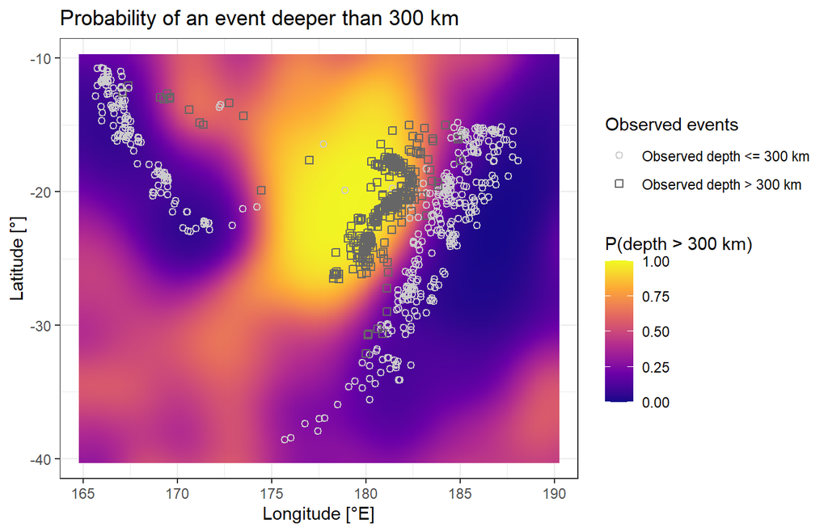

Posterior probability of a deep event, $P(\text{depth} > 300\,\text{km} \mid \text{long}, \text{lat})$, from the two-dimensional SLGP. Observed epicentres are overlaid. The map isolates the deep intraslab seismicity of the subducting plate.

```r
R> threshold <- 300
R> grid2D_cdf <- grid2D
R> grid2D_cdf$depth <- threshold
R> pred_cdf <- predict(modelMAP2D, type = "cdf", newdata = grid2D_cdf)
R> grid2D_cdf$exceed <- 1 - pred_cdf$cdf_1
R>
R> df_train2 <- df_train %>%
+    mutate(depth_class = ifelse(depth > threshold,
+                                "Observed depth > 300 km",
+                                "Observed depth <= 300 km"))
R>
R> ggplot() +
+    geom_raster(data = grid2D_cdf,
+                aes(x = long, y = lat, fill = exceed),
+                interpolate = TRUE) +
+    geom_point(data = df_train2,
+               aes(x = long, y = lat, shape = depth_class, colour = depth_class),
+               inherit.aes = FALSE,
+               size = 1.7,
+               stroke = 0.6) +
+    scale_shape_manual(name = "Observed events",
+                       values = c("Observed depth > 300 km" = 0,
+                                  "Observed depth <= 300 km" = 1)) +
+    scale_colour_manual(name = "Observed events",
+                        values = c("Observed depth > 300 km" = "grey40",
+                                   "Observed depth <= 300 km" = "grey80")) +
+    scale_fill_viridis_c(name = paste0("P(depth > ", threshold, " km)"),
+                         limits = c(0, 1),
+                         option = "plasma") +
+    coord_cartesian(xlim = range_xlong,
+                    ylim = range_xlat) +
+    labs(x = "Longitude [°E]",
+         y = "Latitude [°]",
+         title = paste0("Probability of an event deeper than ", threshold, " km")) +
+    theme_bw()  +
+    theme(legend.position = "right",
+          legend.key = element_rect(fill = "white", colour = NA))
```

```r
R>
R> ggsave("./Figures/exceed2D.pdf", width = 6, height = 4)
```

This single map summarises a genuinely spatial, distribution-valued object: at every location it reports not a point prediction but a probability derived from the full conditional law, and it does so continuously across the region, including where events are sparse. We stress the reading is most reliable where the epicentres are dense: in the poorly sampled corners of the domain the field is an extrapolation of the smooth GP prior and should be interpreted with the corresponding caution

This kind of output is a coherent field of conditional distributions over a two-dimensional spatial index, from scattered and replicate-free data, with out-of-sample calibration. It is, to our knowledge, not directly available from existing conditional density estimation software, and it is the setting for which the SLGP was designed.

## Simulating from the fitted field

The fitted object is a full generative model, not only a density evaluator. `simulate()` draws synthetic responses at chosen locations by inverse-transform sampling from the predictive CDF, which is useful for propagating distributional uncertainty into downstream computations.

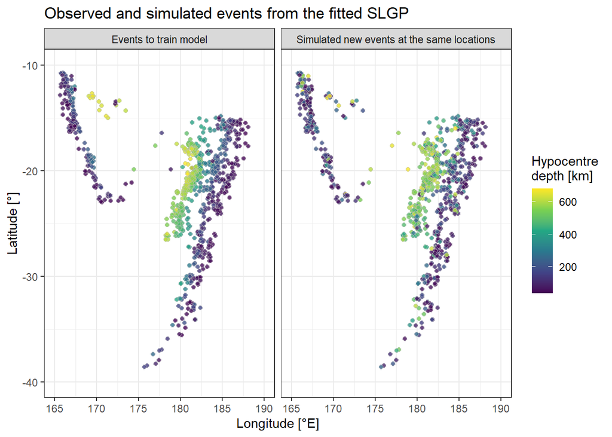

```r
R> newX <- df[, c("long", "lat")]
R> sims <- simulate(modelMAP2D, nsim = 1, newdata = newX, seed=0)
R>
R> df_obs <- df %>%
+    mutate(event_type = "Events to train model")
R>
R> df_sim <- sims %>%
+    mutate(event_type = "Simulated new events at the same locations")
R>
R> df_plot <- bind_rows(df_obs, df_sim) %>%
+    mutate(event_type = factor(event_type,
+                               levels = c("Events to train model",
+                                          "Simulated new events at the same locations")))
R>
R> ggplot(df_plot, aes(x = long, y = lat, fill = depth)) +
+    geom_point(size = 1.5, alpha = 0.8, pch = 21, col = "grey", alpha=0.8) +
+    scale_fill_viridis_c(name = "Hypocentre\ndepth [km]",
+                         limits = range_response,
+                         option = "viridis") +
+    coord_cartesian(xlim = range_xlong, ylim = range_xlat) +
+    facet_wrap(~ event_type, nrow = 1) +
+    ggtitle("Observed and simulated events from the fitted SLGP") +
+    labs(x = "Longitude [°E]",
+         y = "Latitude [°]") +
+    theme_bw()
```

```r
R>
R>
R> ggsave("Figures/simulate.pdf", width = 8, height = 4)
```

Frohlich, Cliff. 2006. *Deep Earthquakes*. Cambridge University Press.

Isacks, Bryan, Jack Oliver, and Lynn R. Sykes. 1968. “Seismology and the New Global Tectonics.” *Journal of Geophysical Research* 73 (18): 5855–99. https://doi.org/10.1029/JB073i018p05855.

R Core Team. 2025. *R: A Language and Environment for Statistical Computing*. R Foundation for Statistical Computing. https://www.R-project.org/.